# Blocking records for deduplication

Maciej Beręsewicz

# 1 Setup

Read required packages.

```r
library(blocking)
library(data.table)
```

Read the `RLdata500` data (taken from the RecordLinkage package).

```r
data(RLdata500)
head(RLdata500)
```

| fname_c1 | fname_c2 | lname_c1 | lname_c2 | by | bm | bd | rec_id | ent_id |
| --- | --- | --- | --- | --- | --- | --- | --- | --- |
| CARSTEN | NA | MEIER | NA | 1949 | 7 | 22 | 1 | 34 |
| GERD | NA | BAUER | NA | 1968 | 7 | 27 | 2 | 51 |
| ROBERT | NA | HARTMANN | NA | 1930 | 4 | 30 | 3 | 115 |
| STEFAN | NA | WOLFF | NA | 1957 | 9 | 2 | 4 | 189 |
| RALF | NA | KRUEGER | NA | 1966 | 1 | 13 | 5 | 72 |
| JUERGEN | NA | FRANKE | NA | 1929 | 7 | 4 | 6 | 142 |

This dataset contains 500 rows with 450 entities.

# 2 Blocking for deduplication

Now we create a new column that concatenates the information in each row.

```r
RLdata500[, id_count :=.N, ent_id] ## how many times given unit occurs
RLdata500[is.na(fname_c2), fname_c2:=""]
RLdata500[is.na(lname_c2), lname_c2:=""]
RLdata500[, bm:=sprintf("%02d", bm)] ## add leading zeros to month
RLdata500[, bd:=sprintf("%02d", bd)] ## add leading zeros to month
RLdata500[, txt:=tolower(paste0(fname_c1,fname_c2,lname_c1,lname_c2,by,bm,bd))]
head(RLdata500)
```

| fname_c1 | fname_c2 | lname_c1 | lname_c2 | by | bm | bd | rec_id | ent_id | id_count | txt |
| --- | --- | --- | --- | --- | --- | --- | --- | --- | --- | --- |
| CARSTEN |  | MEIER |  | 1949 | 07 | 22 | 1 | 34 | 1 | carstenmeier19490722 |
| GERD |  | BAUER |  | 1968 | 07 | 27 | 2 | 51 | 2 | gerdbauer19680727 |
| ROBERT |  | HARTMANN |  | 1930 | 04 | 30 | 3 | 115 | 1 | roberthartmann19300430 |
| STEFAN |  | WOLFF |  | 1957 | 09 | 02 | 4 | 189 | 1 | stefanwolff19570902 |
| RALF |  | KRUEGER |  | 1966 | 01 | 13 | 5 | 72 | 1 | ralfkrueger19660113 |
| JUERGEN |  | FRANKE |  | 1929 | 07 | 04 | 6 | 142 | 1 | juergenfranke19290704 |

In the next step we use the newly created column in the `blocking` function. If we specify verbose, we get information about the progress.

```r
set.seed(2024)
df_blocks <- blocking(x = RLdata500$txt, ann = "nnd", verbose = 1, graph = TRUE)
```

```
#> ===== creating tokens =====
#> ===== starting search (nnd, x, y: 500, 500, t: 429) =====
#> ===== creating graph =====
```

Results are as follows:

```r
df_blocks
```

```
#> ========================================================
#> Blocking based on the nnd method.
#> Number of blocks: 133.
#> Number of columns used for blocking: 429.
#> Reduction ratio: 0.9917.
#> ========================================================
#> Distribution of the size of the blocks:
#>  2  3  4  5  6  7  8  9 10 11 17
#> 47 34 18 12  8  5  3  3  1  1  1
```

Structure of the object is as follows:

- `result` – a `data.table` with identifiers and block IDs,
- `method` – the method used,
- `deduplication` – whether deduplication was applied,
- `representation` – whether shingles or vectors were used,
- `metrics` – standard metrics and based on the `igraph::compare` methods for comparing graphs (here NULL),
- `confusion` – confusion matrix (here NULL),
- `colnames` – column names used for the comparison,
- `graph` – an `igraph` object mainly for visualisation.

```r
str(df_blocks,1)
```

```
#> List of 8
#>  $ result        :Classes 'data.table' and 'data.frame': 367 obs. of  4 variables:
#>   ..- attr(*, ".internal.selfref")=<externalptr>
#>  $ method        : chr "nnd"
#>  $ deduplication : logi TRUE
#>  $ representation: chr "shingles"
#>  $ metrics       : NULL
#>  $ confusion     : NULL
#>  $ colnames      : chr [1:429] "86" "ap" "av" "bf" ...
#>  $ graph         :Class 'igraph'  hidden list of 10
#>  - attr(*, "class")= chr "blocking"
```

Plot connections.

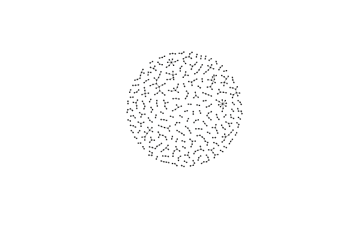

```r
plot(df_blocks$graph, vertex.size=1, vertex.label = NA)
```

The resulting `data.table` has four columns:

- `x` – reference dataset (i.e. `RLdata500`) – this may not contain all units of `RLdata500`,
- `y` - query (each row of `RLdata500`) – this may not contain all units of `RLdata500`,
- `block` – the block ID,
- `dist` – distance between objects.

```r
head(df_blocks$result)
```

| x | y | block | dist |
| --- | --- | --- | --- |
| 1 | 64 | 33 | 0.4737987 |
| 2 | 43 | 1 | 0.0807453 |
| 2 | 486 | 1 | 0.4102322 |
| 3 | 450 | 88 | 0.4326335 |
| 4 | 234 | 12 | 0.5256584 |
| 5 | 128 | 2 | 0.5133357 |

Create long `data.table` with information on blocks and units from original dataset.

```r
df_block_melted <- melt(df_blocks$result, id.vars = c("block", "dist"))
df_block_melted_rec_block <- unique(df_block_melted[, .(rec_id=value, block)])
head(df_block_melted_rec_block)
```

| rec_id | block |
| --- | --- |
| 1 | 33 |
| 2 | 1 |
| 3 | 88 |
| 4 | 12 |
| 5 | 2 |
| 6 | 33 |

We add block information to the final dataset.

```r
RLdata500[df_block_melted_rec_block, on = "rec_id", block_id := i.block]
head(RLdata500)
```

| fname_c1 | fname_c2 | lname_c1 | lname_c2 | by | bm | bd | rec_id | ent_id | id_count | txt | block_id |
| --- | --- | --- | --- | --- | --- | --- | --- | --- | --- | --- | --- |
| CARSTEN |  | MEIER |  | 1949 | 07 | 22 | 1 | 34 | 1 | carstenmeier19490722 | 33 |
| GERD |  | BAUER |  | 1968 | 07 | 27 | 2 | 51 | 2 | gerdbauer19680727 | 1 |
| ROBERT |  | HARTMANN |  | 1930 | 04 | 30 | 3 | 115 | 1 | roberthartmann19300430 | 88 |
| STEFAN |  | WOLFF |  | 1957 | 09 | 02 | 4 | 189 | 1 | stefanwolff19570902 | 12 |
| RALF |  | KRUEGER |  | 1966 | 01 | 13 | 5 | 72 | 1 | ralfkrueger19660113 | 2 |
| JUERGEN |  | FRANKE |  | 1929 | 07 | 04 | 6 | 142 | 1 | juergenfranke19290704 | 33 |

We can check in how many blocks the same entities (`ent_id`) are observed. In our example, all the same entities are in the same blocks.

```r
RLdata500[, .(uniq_blocks = uniqueN(block_id)), .(ent_id)][, .N, uniq_blocks]
```

| uniq_blocks | N |
| --- | --- |
| 1 | 450 |

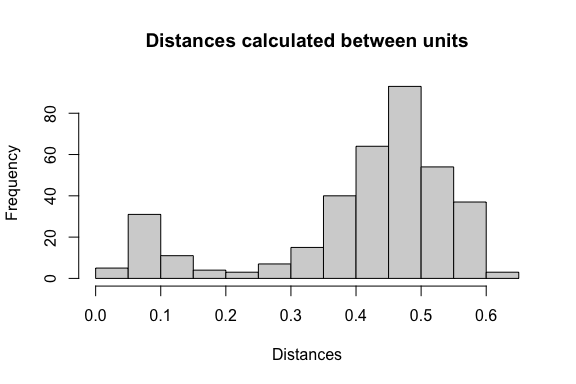

```r
hist(df_blocks$result$dist, xlab = "Distances", ylab = "Frequency", breaks = "fd",
     main = "Distances calculated between units")
```

Finally, we can visualise the result based on the information whether block contains matches or not.

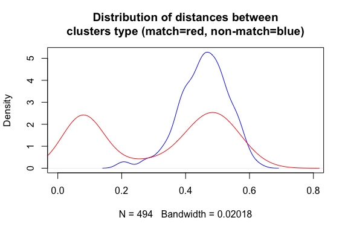

```r
df_for_density <- copy(df_block_melted[block %in% RLdata500$block_id])
df_for_density[, match:= block %in% RLdata500[id_count == 2]$block_id]

plot(density(df_for_density[match==FALSE]$dist), col = "blue", xlim = c(0, 0.8),
     main = "Distribution of distances between\nclusters type (match=red, non-match=blue)")
lines(density(df_for_density[match==TRUE]$dist), col = "red", xlim = c(0, 0.8))
```